# Lista de Exercícios 1 - Resolução

Análise Multivariada

Autor

Prof. Dr. Washington S. da Silva

Data de Publicação

6 de novembro de 2023

## Questão 1

Insira um novo trecho de código R abaixo, digite e execute o comando: Sys.time()

**Solução**

```r
Sys.time()
```

```
[1] "2023-11-06 13:58:29 -03"
```

## Questão 2

Preencha os espaços em branco:

**Solução**

1. 10 + 5*x
2. rnorm(n = 25, mean = 0, sd = 10)

## Questão 3

### 3.1

Modele `y` como uma função de `z` usando `lm(y ~ z, data = d)` e salve os resultados em um objeto chamado `mod_sim2`, veja os resultados usando a função `summary()`. Qual modelo foi estimado? Qual é o desvio padrão estimado do erro aleatório normalmente distribuído?

**Solução**

```r
set.seed(4)
d$z <- runif(25, min = -100, max = 100)
```

```r
mod_sim2 <- lm(y ~ z, data = d)
summary(mod_sim2)
```

```
Call:
lm(formula = y ~ z, data = d)

Residuals:
    Min      1Q  Median      3Q     Max
-68.231 -33.002   3.679  30.840  61.302

Coefficients:
            Estimate Std. Error t value Pr(>|t|)
(Intercept)  73.0003     7.5254   9.701 1.35e-09 ***
z             0.2312     0.1213   1.906   0.0692 .
---
Signif. codes:  0 '***' 0.001 '**' 0.01 '*' 0.05 '.' 0.1 ' ' 1

Residual standard error: 36.36 on 23 degrees of freedom
Multiple R-squared:  0.1364,    Adjusted R-squared:  0.0989
F-statistic: 3.634 on 1 and 23 DF,  p-value: 0.06917
```

O modelo estimado foi:

$$\hat{y} = 73 + 0.23\times z$$

A estimativa do erro padrão residual foi 36.36.

### 3.2

Use o modelo para simular um histogramas ou densidade e compare com o histograma e densidade original de `d$y`. Execute o código várias vezes para ver como a curva de densidade gerada pelo modelo varia.

**Solução**

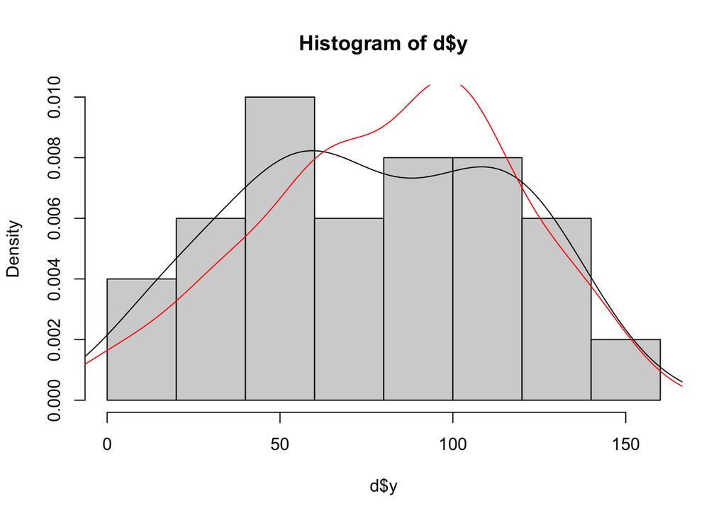

```r
hist(d$y, freq = FALSE)
lines(density(d$y))
lines(density(73.0003 + d$z*0.2312 + rnorm(25, 0, sd = 36.36)), col = "red")
```

## Questão 4

### 4.1

Escreva código para modelar `log(totalvalue)` como função de `fullbath` e `finsqft.` Chame seu modelo de `m3`

**Solução**

```r
url <- 'https://raw.githubusercontent.com/clayford/dataviz_with_ggplot2/master/alb_homes.csv'
homes <- readr::read_csv(file = url)
```

```r
m3 <- lm(log(totalvalue) ~ fullbath + finsqft, data = homes)
```

### 4.2

Escreve o código para produzir os gráficos de diagnóstico dos resíduos

**Solução**

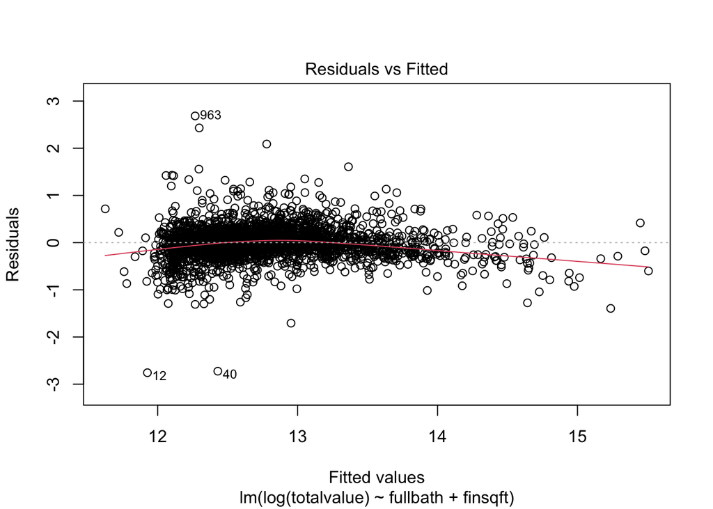

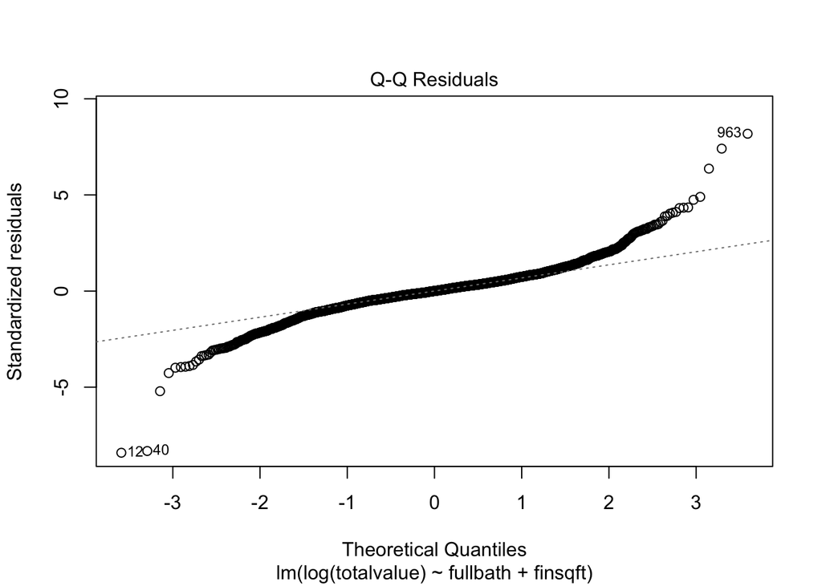

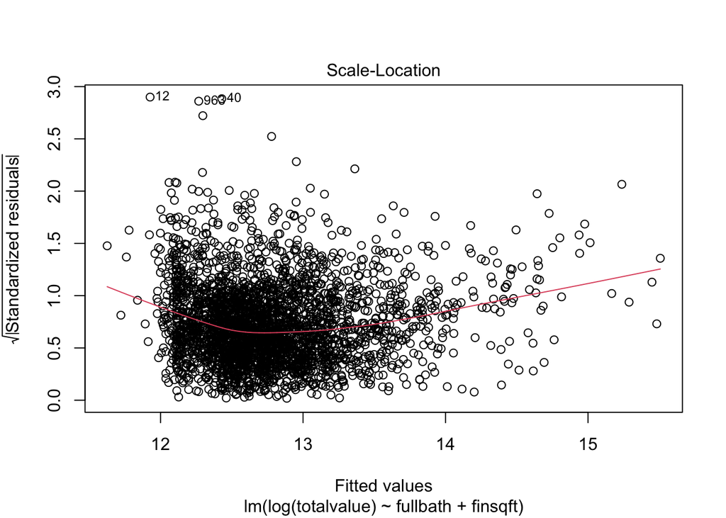

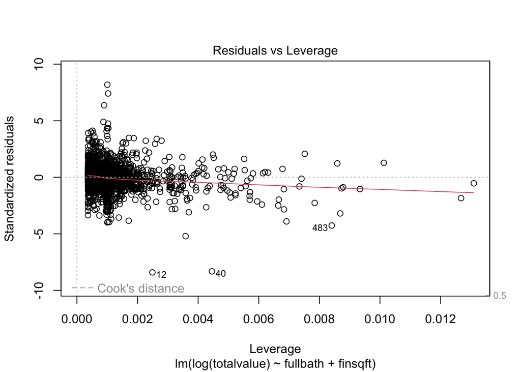

```r
plot(m3)
```

**Observações:**

1. A curvatura que pode ser observada no gráfico dos resíduos ($\hat{e}$) versus os valores ajustados ($\hat{y}$, primeiro gráfico) mostra evidência de algum padrão não linear que não foi captado pelo modelo. O mesmo comportamento pode ser observado no gráfico dos resíduos padronizados versus os valores ajustados (terceiro gráfico).
2. O gráfico quantil-quantil dos resíduos revela uma distribuição com caudas pesadas, isto é, a distribuição dos resíduos contém mais outliers nas caudas do que uma distribuição normal (veja o slide 49 sobre os modelos de regressão linear). Este não é um grande problema para os procedimentos de inferência, assimetrias na distribuição dos resíduos é o desvio mais grave e que compromente os procedimentos que supõe que os resíduos seguem uma distribuição aproximadamente normal.

### 4.3

Como interpretamos o coeficiente estimado da variáveil `fullbath`?

**Solução**

```r
round(coef(m3), 3)
```

```
(Intercept)    fullbath     finsqft
     11.567       0.162       0.000
```

No slide 33 sobre os modelos de regressão linear, podemos ver que a interpretação da estimativa de um parâmetro associado a $x$ em que a transformação logarítmica foi aplicada somente a $y$ é: A variação de 1 unidade em $X$ está associada a uma variação média de 100*$\beta$ % em $Y$.

Portanto, adicionar um banheiro completo aumenta, em média, o valor da casa em cerca de 16%, mantidas constantes as demais variáveis.

### 4.4.

Escreva código para simular os dados do modelo, em seguida, compare com o `totalvalue` observado. Este parece ser um bom modelo?

**Solução**

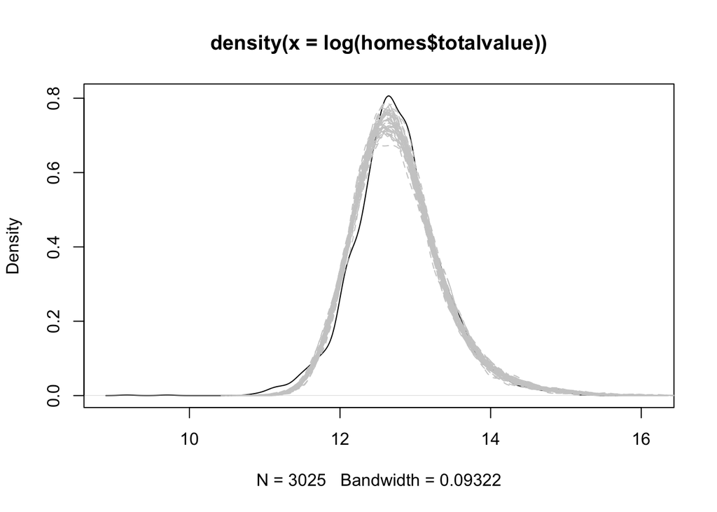

```r
sim_m3 <- simulate(m3, nsim = 50)
plot(density(log(homes$totalvalue)))
for (i in 1:50) lines(density(sim_m3[[i]]), lty = 2, col = "grey80")
```

Eu diria que o modelo é razoável, e pode ser melhorado.

## Questão 5

### 5.1

Escreva o código para modelar `log(totalvalue)` como função de `fullbath`, `finsqft` e `cooling`. Chame seu modelo de `m5`.

**Solução**

```r
m5 <- lm(log(totalvalue) ~ fullbath + finsqft + cooling, data = homes)
```

### 5.2

Qual é a interpretação do coeficente de `cooling`?

**Solução**

```r
round(coef(m5), 3)
```

```
          (Intercept)              fullbath               finsqft
               11.654                 0.136                 0.000
coolingNo Central Air
               -0.205
```

Em média, o valor de uma casa sem Ar Central é cerca de 20 % menor do que uma casa equivalente com Ar Central, mantidas as demais variáveis constantes.

## Questão 6

### 6.1

Escreva código para modelar `log(totalvalue)` como função de `fullbath`, `finsqft`, `cooling` e a interação entre `finsqft` e `cooling`. Chame seu modelo de `m7`. A interação é importante?

**Solução**

```r
m7 <- lm(log(totalvalue) ~ fullbath + finsqft + cooling + finsqft:cooling,
        data = homes)
summary(m7)
```

```
Call:
lm(formula = log(totalvalue) ~ fullbath + finsqft + cooling +
    finsqft:cooling, data = homes)

Residuals:
    Min      1Q  Median      3Q     Max
-2.6473 -0.1556 -0.0031  0.1367  2.6224

Coefficients:
                                Estimate Std. Error t value Pr(>|t|)
(Intercept)                    1.166e+01  1.826e-02 638.778  < 2e-16 ***
fullbath                       1.359e-01  9.069e-03  14.983  < 2e-16 ***
finsqft                        3.961e-04  8.721e-06  45.417  < 2e-16 ***
coolingNo Central Air         -2.889e-01  4.156e-02  -6.952  4.4e-12 ***
finsqft:coolingNo Central Air  5.902e-05  2.591e-05   2.278   0.0228 *
---
Signif. codes:  0 '***' 0.001 '**' 0.01 '*' 0.05 '.' 0.1 ' ' 1

Residual standard error: 0.3222 on 3020 degrees of freedom
Multiple R-squared:  0.7113,    Adjusted R-squared:  0.7109
F-statistic:  1860 on 4 and 3020 DF,  p-value: < 2.2e-16
```

### 6.2

Visualize a interação usando a função `ggpredict`. Use `[1000:4000 by=500]` para definir o intervalo de `finsqft` no eixo x. Quão notável é essa interação?

**Solução**

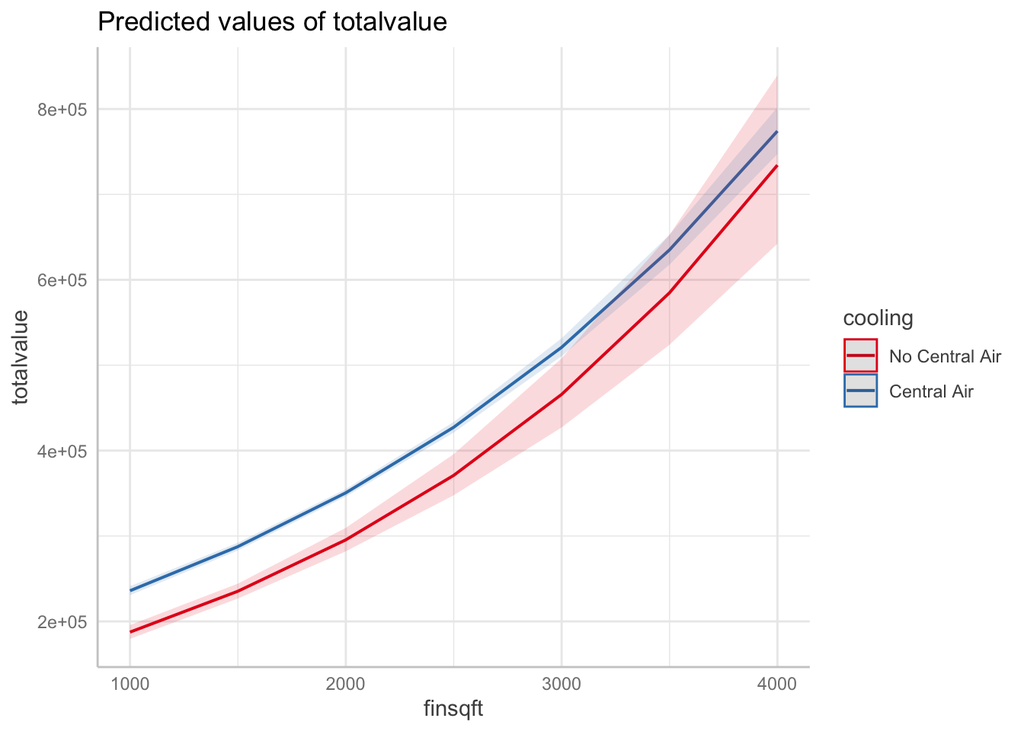

```r
plot(ggeffects::ggpredict(m7, terms = c("finsqft[1000:4000 by=500]", "cooling")))
```

Observando o gráfico de efeitos, o efeito de `finsqft` parece diminuir um pouco em relação às casas com e sem ar central, ou seja, à medida que os pés quadrados construídos aumentam, a diferença entre o valor total das casas com e sem ar central diminui.

## Questão 7

### 7.1

Escreva código para modelar `log(totalvalue)` como função de `finsqft` com um spline natural com `df = 5`, `cooling`, e a interação de `cooling` e `finsqft` (spline natural com `df = 5`). Chame seu modelo de `nlm4`.

**Solução**

```r
nlm4 <- lm(log(totalvalue) ~ splines::ns(finsqft, df = 5) + cooling +
             splines::ns(finsqft, df = 5):cooling, data = homes)
```

### 7.2

Use a função `anova` para verificar se a interação parece necessária. O que você acha?

**Solução**

```r
anova(nlm4)
```

```
Analysis of Variance Table

Response: log(totalvalue)
                                       Df Sum Sq Mean Sq  F value Pr(>F)
splines::ns(finsqft, df = 5)            5 749.09 149.819 1392.840 <2e-16 ***
cooling                                 1  11.98  11.980  111.376 <2e-16 ***
splines::ns(finsqft, df = 5):cooling    5   0.97   0.193    1.796 0.1102
Residuals                            3013 324.09   0.108
---
Signif. codes:  0 '***' 0.001 '**' 0.01 '*' 0.05 '.' 0.1 ' ' 1
```

O valor-p do teste F da interação foi 0.1102, que é superior aos níveis usuais de siginificância (0,05 e 0,1), assim, apenas pelo resultado do teste F, a interação não parece importante.

Entretanto, como vimos, o fato de uma interação não ser significativa não implica necessariamente que não seja relvante ou que não valha a pena incluí-la no modelo, precisamos recorrer a gráficos de efeitos para analisar a questão com mais propriedade.

### 7.3

Crie um gráfico de efeito de `finsqft` por `resfriamento`. Tente `[1000:5000 by=250]` para o intervalo de valores de `finsqft`.

**Solução**

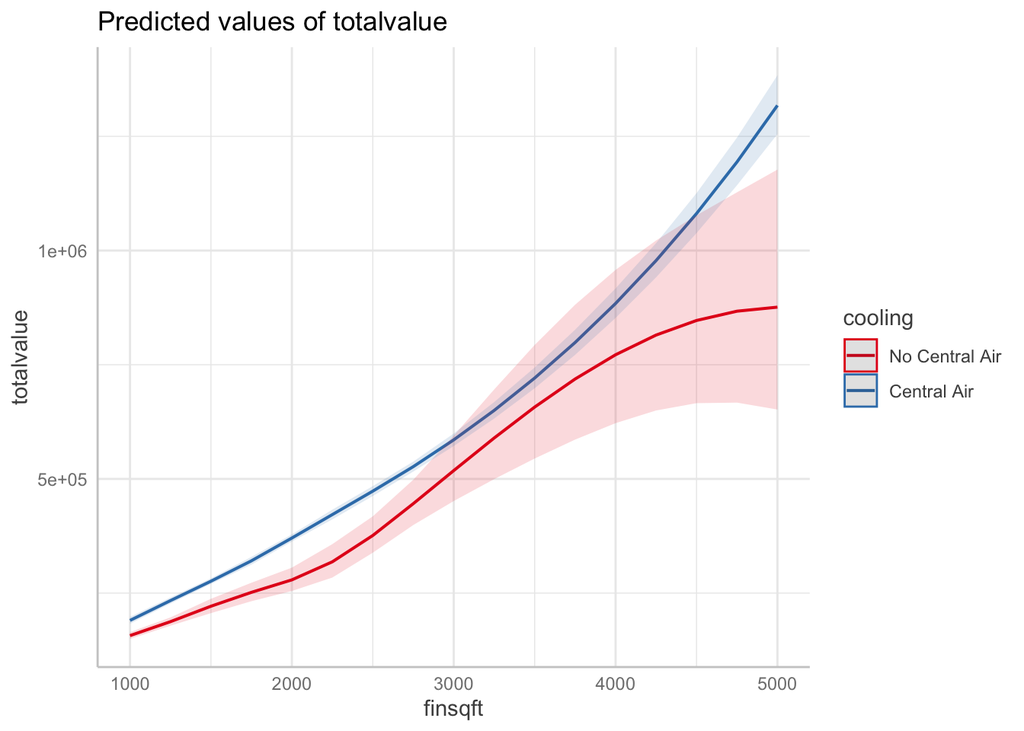

```r
plot(ggeffects::ggpredict(nlm4, terms = c("finsqft[1000:5000 by=250]", "cooling")))
```

Incorporando a não linearidade ao modelo com splines naturais e alterando a configuração do gráfico de efeitos, a interação entre `finsqft` e `cooling` parece mais consistente.

O efeito de `finsqft` aumenta substancialmente em relação às casas com e sem ar central para casas com mais pés quadrados construídos, especificamente, a partir de 3.600 pés quadrados construídos aproximadamente.

**Pontos Importantes**

Este exercício de modelagem linear busca enfatizar, entre outros pontos:

1. que os métodos estatísticos fornecem métodos muito úteis para entendermos, para aprendermos sobre diversos tipos de fenômenos.
2. que estes métodos estatísticos não podem ser aplicados como receitas determínísticas, que na verdade estes métodos fornecem uma forma de pensar o entendimento de um fenômeno.
3. que *significância estatística* não implica em *significância prática*. A questão das interações exibe de forma explícita a necessidade desta distinção.